# Does the leading digit of “naturally occurring numbers” (i.e., population and GDP per Capita) follow Benford’s law?

Shuang Liu, Qiwei Men

11/28/2019

### Benford’s Law

- The law states that in many naturally occurring collections of numbers, the leading significant digit is likely to be small. For example, in sets that obey the law, the number 1 appears as the leading significant digit about 30% of the time, while 9 appears as the leading significant digit less than 5% of the time.
- A set of decimal numbers is said to satisfy Benford’s law if the leading digit $d\ (d \in \{1, ..., 9\})$ occurs with probability $P(d) = log_{10}(\frac{d+1}{d}) = log_{10}(1+\frac{1}{d})$. The leading digits in such a set thus have the following distribution:

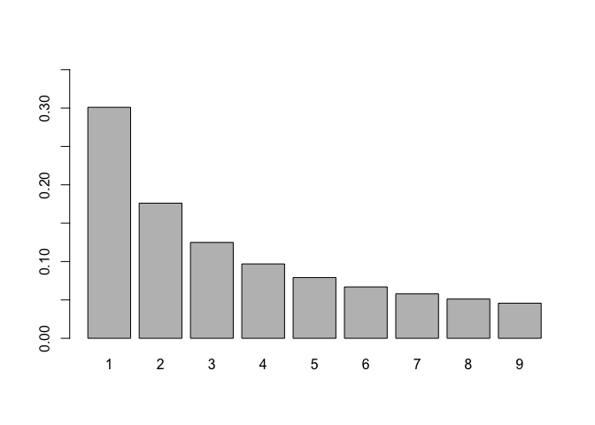

```r
# Benford's Law
benlaw <- function (d){log10(1 + 1 / d)}
digits <- 1:9
barplot(benlaw(digits), names.arg = digits, xlab = NULL, ylim = c(0, .35))
```

### Leading digits of population and GDP per Capita in 2007

- Using data from 2007, compare the observed distribution of the leading digits in population to the distribution predicted by Benford’s law.

```r
# function to extract the first digit of a number
bben <- function(k){as.numeric(head(strsplit(as.character(k),'')[[1]],n=1))}
```

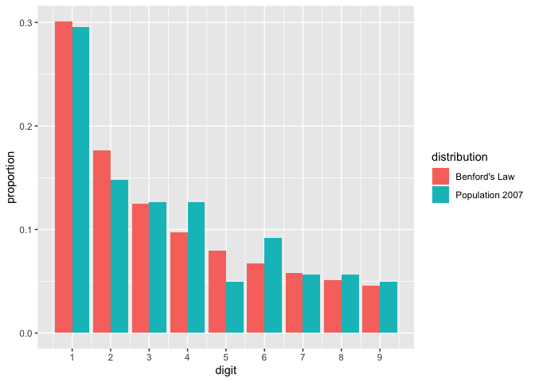

```r
# compare Benford's law and the leading digits of population in 2007
pop.prop.2007 <- gapminder %>%
  subset(year == 2007) %>%
  select(pop) %>%
  rowwise() %>%
  mutate(digit = bben(pop)) %>%
  table() %>%
  colSums()/nrow(subset(gapminder, year == 2007)) %>%
  as.numeric()

df <- rbind(data_frame(digit = 1:9,
                       proportion = pop.prop.2007,
                       distribution = "Population 2007"),
            data_frame(digit = 1:9,
                       proportion = benlaw(digit),
                       distribution = "Benford's Law"))

ggplot(df, aes(digit, proportion)) +
  geom_col(aes(fill = distribution), position = "dodge") +
  scale_x_continuous(breaks = 1:9)
```

- Using data from 2007, compare the observed distribution of the leading digits in GDP per Capita to the distribution predicted by Benford’s law.

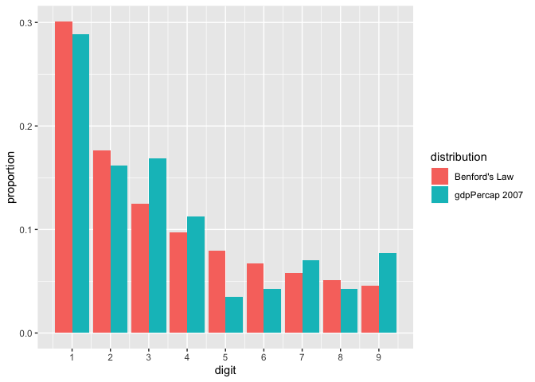

## Chi-square Goodness-of-fit Test

- Test if a sample of data came from a population with a specific distribution. The chi-square goodness-of-fit test can be applied to discrete distributions. In other words, it is used to determine whether there is a significant difference between the expected frequencies and the observed frequencies in one or more categories.
- $H_0$: The leading digits of population in 2007 follows Benford’s law.
- $H_a$: The leading digits of population in 2007 does not follow Benford’s law.
- Chi-square Statistic:
  - $Q_{k-1} = \sum_{i=1}^{k}\frac{(O_i-np_i)^2}{np_i}$
  - $k$: number of digits (=9)
  - $k-1$: degree of freedom (=8)
  - $O_i$: observed count of digit $i$
  - $n$: total number of observations
  - $p_i$: probability of digit $i$ predicted by Benford’s law.
- Let’s estimate the p-value by Monte Carlo.

### Sampling distribution of the Chi-square statistic

```r
# function to simulate a sample of digits from Benford's Law and count the frequency of each digit
count.sim <- function(n){
  # n: sample size
  sim <- sample(x=c(1:9), size=n, replace=TRUE, prob = benlaw(1:9))
  count <- numeric()
  for (i in 1:9){
    count[i] <- sum(sim == i)
  }
  return(count)
}
```

```r
# sample size
n <- nrow(subset(gapminder, year == 2007))
# expected count for each digit from Benford's law
E <- n*benlaw(1:9)
```

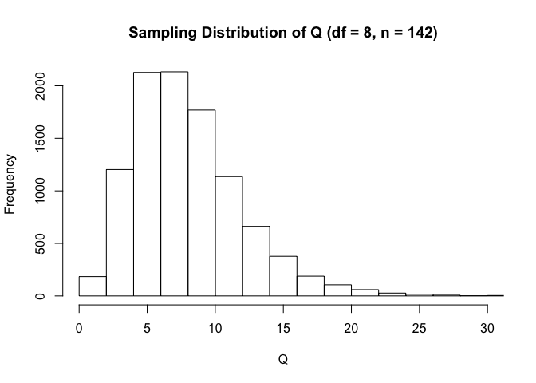

```r
# sampling distribution of Chi-square statistic
hist(replicate(10000, chi <- sum((count.sim(n)-E)^2/E)), main = "Sampling Distribution of Q (df = 8, n = 142)", xlab = "Q", breaks = 20, xlim = c(0,30))
```

### Critical Value for 2007 Population

```r
# observed count of each digit in 2007 data
pop.count.2007 <- gapminder %>%
  subset(year == 2007) %>%
  select(pop) %>%
  rowwise() %>%
  mutate(digit = bben(pop)) %>%
  table() %>%
  colSums() %>%
  as.numeric()

# critical value
pop.2007.crit <- sum((pop.count.2007-E)^2/E)
```

The critical value is **4.97**.

### P-value

```r
# p-value
p.pop.2007 <- sum(replicate(10000, chi <- sum((count.sim(n)-E)^2/E)) >= pop.2007.crit)/10000
```

The estimated p-value is **0.76**.

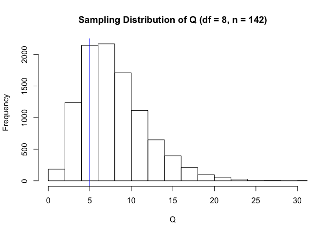

```r
# built-in function p-value
bp1 <- pchisq(pop.2007.crit,8,lower.tail = FALSE)
```

The p-value given by the built-in function `pchisq` is **0.76**, which is very similar to what we got from our Monte Carlo sampling distribution.

### Critical Value and P-value for 2007 GDP per Capita

The critical value is **11.28**.

The estimated p-value is **0.18**.

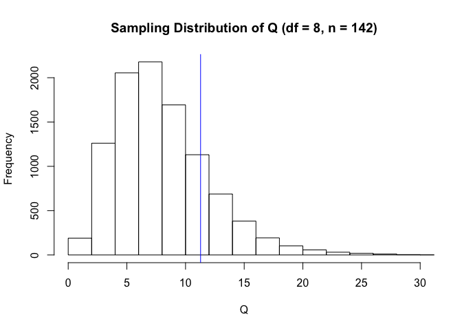

The p-value given by the built-in function `pchisq` is **0.19**, which is very similar to what we got from Monte Carlo.

### Compare empirical distribution and theoretical distribution

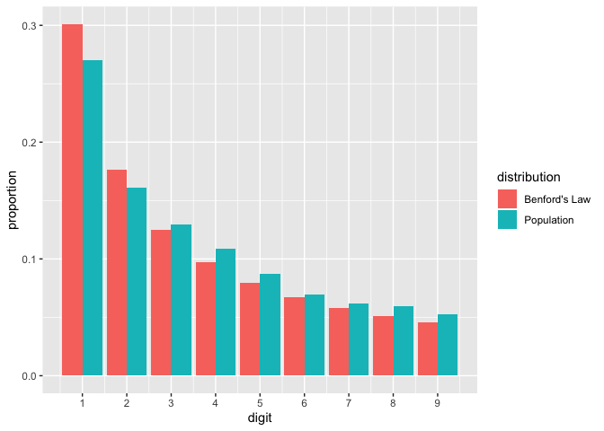

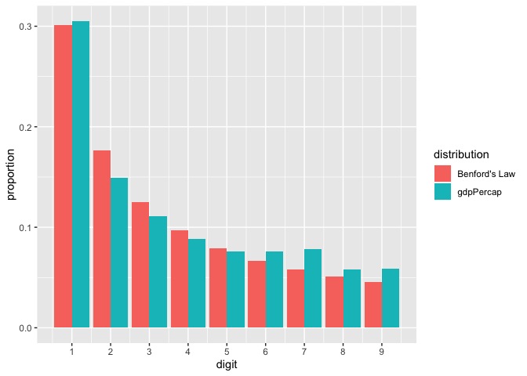

### Sampling distribution:

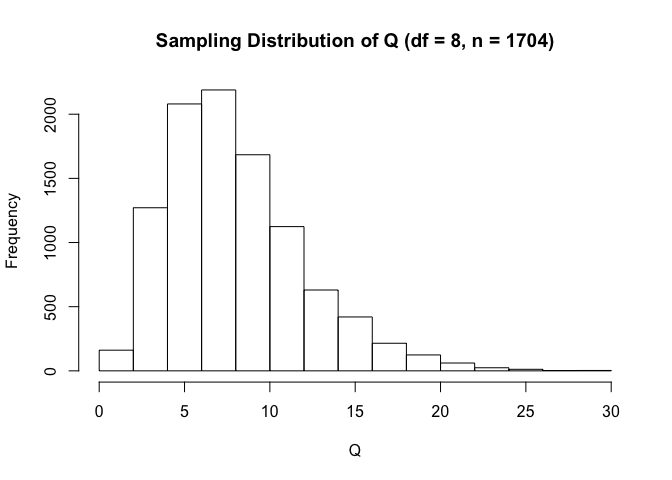

### Critical value and p-value, population

- The critical value is **16.61**. The estimated p-value is **0.04**.

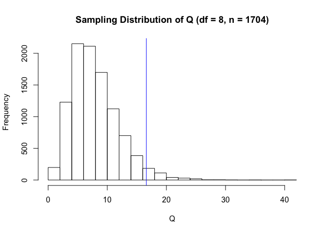

- The p-value given by the built-in function `pchisq` is **0.03**, which is very similar to what we got from Monte Carlo.

### Critical value and p-value, GDP per Capita

- The critical value is **33.81**. The estimated p-value is **0**.

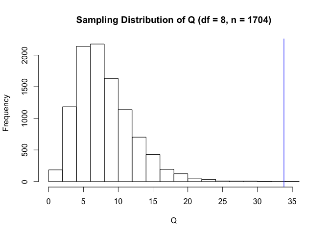

- The p-value given by the built-in function `pchisq` is **0**, which is very similar to what we got from Monte Carlo.
- In practice, applications of Benford’s Law for fraud detection routinely use more than the first digit.
- Package: `benford.analysis`
- One can select the number of digits to do the test.

```r
# library(benford.analysis)
# pop.bo2 <- benford(gapminder$pop, number.of.digits = 3)
# chisq(pop.bo2)
```